# Proteomics data analysis: mouse Tcell example with RCB designs

Lieven Clement

5 July 2019

# 1 Background

Duguet et al. 2017 compared the proteomes of mouse regulatory T cells (Treg) and conventional T cells (Tconv) in order to discover differentially regulated proteins between these two cell populations. For each biological repeat the proteomes were extracted for both Treg and Tconv cell pools, which were purified by flow cytometry. The data in data/quantification/mouseTcell on the pdaData repository are a subset of the data PXD004436 on PRIDE.

We will use a subset of the data with a randomized complete block (RCB) design, i.e. the dataset consists of four mice for which the proteome of both conventional and regulatory T cells are assessed.

# 2 Data

We first import the peptides.txt file. This is the file that contains your peptide-level intensities. For a MaxQuant search [6], this peptides.txt file can be found by default in the “path_to_raw_files/combined/txt/” folder from the MaxQuant output, with “path_to_raw_files” the folder where raw files were saved. In this tutorial, we will use a MaxQuant peptides file from MaxQuant that can be found on the pdaData repository. We will use the MSnbase package to import the data.

We generate the object peptideFile with the path to the peptides.txt file. In this file we will fetch the data from the github repository linked to the pda course: https://statomics.github.io/pda. You can also replace the peptideFile with a string that points to the path of a file on your local hard drive.

With the grepEcols function we find the columns that are containing the expression data of the peptides in the peptides.txt file.

```r
library(MSqRob)
library(MSnbase)
library(tidyverse)
library(limma)
peptidesFile <- "https://raw.githubusercontent.com/statOmics/pda/data/quantification/mouseTcell/peptidesRCB.txt"
proteinGroupsFile <-"https://raw.githubusercontent.com/statOmics/pda/data/quantification/mouseTcell/proteinGroups.txt"
ecols<-grepEcols(peptidesFile, "Intensity ", split = "\t")
```

Next we import the peptide intensities

```r
pepData<-readMSnSet2(peptidesFile,ecol=ecols,fnames="Sequence",sep="\t")
pepData
```

```
## MSnSet (storageMode: lockedEnvironment)
## assayData: 55814 features, 8 samples
##   element names: exprs
## protocolData: none
## phenoData: none
## featureData
##   featureNames: AAAAAAAAAAGAAGGR AAAAAAAAAAGDSDSWDADTFSMEDPVRK ...
##     YYYDKNIIHK (55814 total)
##   fvarLabels: Sequence N.term.cleavage.window ... MS.MS.Count (74
##     total)
##   fvarMetadata: labelDescription
## experimentData: use 'experimentData(object)'
## Annotation:
## - - - Processing information - - -
##  MSnbase version: 2.10.1
```

The pepData object is an MSnSet, a container for the data, features information and experimental annotation. They can be accessed using the accessor functions ‘exprs’ (matrix of intensities, features in rows, samples in columns), ‘fData’ (properties for each feature, peptide or protein, on the rows) and ‘pData’ (properties for the samples on the columns).

We will make use from data wrangling functionalities from the tidyverse package. The %>% operator allows us to pipe the output of one function to the next function.

```r
head(exprs(pepData))
```

```
##                               Intensity.Tconv.M12_2 Intensity.Tconv.M12_3
## AAAAAAAAAAGAAGGR                          111470000             101350000
## AAAAAAAAAAGDSDSWDADTFSMEDPVRK              13303000              10160000
## AAAAAAAGGAAIAVSTGIETATIQK                         0                     0
## AAAAAAGAASGIPGPVAQGIK                             0               7197400
## AAAAAAGPEMVR                              104440000             101950000
## AAAAAAPGGGGGEPR                            11910000              12683000
##                               Intensity.Tconv.M5_inj1
## AAAAAAAAAAGAAGGR                               965070
## AAAAAAAAAAGDSDSWDADTFSMEDPVRK                  235500
## AAAAAAAGGAAIAVSTGIETATIQK                       48225
## AAAAAAGAASGIPGPVAQGIK                          266620
## AAAAAAGPEMVR                                   947110
## AAAAAAPGGGGGEPR                                190550
##                               Intensity.Tconv.M6_inj1 Intensity.Treg.M12_2
## AAAAAAAAAAGAAGGR                                    0             80606000
## AAAAAAAAAAGDSDSWDADTFSMEDPVRK                 6744500                    0
## AAAAAAAGGAAIAVSTGIETATIQK                      314120                    0
## AAAAAAGAASGIPGPVAQGIK                         2904800             12602000
## AAAAAAGPEMVR                                 12747000             44735000
## AAAAAAPGGGGGEPR                               2166100             12555000
##                               Intensity.Treg.M12_3 Intensity.Treg.M5_inj1
## AAAAAAAAAAGAAGGR                         120130000                1668800
## AAAAAAAAAAGDSDSWDADTFSMEDPVRK             14499000                 437460
## AAAAAAAGGAAIAVSTGIETATIQK                        0                 173070
## AAAAAAGAASGIPGPVAQGIK                     14162000                 520550
## AAAAAAGPEMVR                              70512000                1604600
## AAAAAAPGGGGGEPR                           13873000                 361240
##                               Intensity.Treg.M6_inj1
## AAAAAAAAAAGAAGGR                                   0
## AAAAAAAAAAGDSDSWDADTFSMEDPVRK                3881000
## AAAAAAAGGAAIAVSTGIETATIQK                     317830
## AAAAAAGAASGIPGPVAQGIK                        1608500
## AAAAAAGPEMVR                                 4689900
## AAAAAAPGGGGGEPR                              1168900
```

```r
pepData %>% exprs %>% head
```

```
##                               Intensity.Tconv.M12_2 Intensity.Tconv.M12_3
## AAAAAAAAAAGAAGGR                          111470000             101350000
## AAAAAAAAAAGDSDSWDADTFSMEDPVRK              13303000              10160000
## AAAAAAAGGAAIAVSTGIETATIQK                         0                     0
## AAAAAAGAASGIPGPVAQGIK                             0               7197400
## AAAAAAGPEMVR                              104440000             101950000
## AAAAAAPGGGGGEPR                            11910000              12683000
##                               Intensity.Tconv.M5_inj1
## AAAAAAAAAAGAAGGR                               965070
## AAAAAAAAAAGDSDSWDADTFSMEDPVRK                  235500
## AAAAAAAGGAAIAVSTGIETATIQK                       48225
## AAAAAAGAASGIPGPVAQGIK                          266620
## AAAAAAGPEMVR                                   947110
## AAAAAAPGGGGGEPR                                190550
##                               Intensity.Tconv.M6_inj1 Intensity.Treg.M12_2
## AAAAAAAAAAGAAGGR                                    0             80606000
## AAAAAAAAAAGDSDSWDADTFSMEDPVRK                 6744500                    0
## AAAAAAAGGAAIAVSTGIETATIQK                      314120                    0
## AAAAAAGAASGIPGPVAQGIK                         2904800             12602000
## AAAAAAGPEMVR                                 12747000             44735000
## AAAAAAPGGGGGEPR                               2166100             12555000
##                               Intensity.Treg.M12_3 Intensity.Treg.M5_inj1
## AAAAAAAAAAGAAGGR                         120130000                1668800
## AAAAAAAAAAGDSDSWDADTFSMEDPVRK             14499000                 437460
## AAAAAAAGGAAIAVSTGIETATIQK                        0                 173070
## AAAAAAGAASGIPGPVAQGIK                     14162000                 520550
## AAAAAAGPEMVR                              70512000                1604600
## AAAAAAPGGGGGEPR                           13873000                 361240
##                               Intensity.Treg.M6_inj1
## AAAAAAAAAAGAAGGR                                   0
## AAAAAAAAAAGDSDSWDADTFSMEDPVRK                3881000
## AAAAAAAGGAAIAVSTGIETATIQK                     317830
## AAAAAAGAASGIPGPVAQGIK                        1608500
## AAAAAAGPEMVR                                 4689900
## AAAAAAPGGGGGEPR                              1168900
```

```r
pepData %>% sampleNames
```

```
## [1] "Intensity.Tconv.M12_2"   "Intensity.Tconv.M12_3"
## [3] "Intensity.Tconv.M5_inj1" "Intensity.Tconv.M6_inj1"
## [5] "Intensity.Treg.M12_2"    "Intensity.Treg.M12_3"
## [7] "Intensity.Treg.M5_inj1"  "Intensity.Treg.M6_inj1"
```

```r
sampleNames(pepData) <- pepData %>% sampleNames %>% str_replace(., pattern="Intensity.", replacement="")
```

Next we will add information on the proteins to the feature data. The feature data of the object pepData contains information for each peptide in the experiment. This info on the proteins can be found in the proteingroups.txt file of maxquant. The peptides.txt file contains many data on each feature (peptide). We will only retain specified columns Protein, Sequence, Reverse and Potential.Contaminant, indicating the protein, peptide sequence, if the peptide is a decoy and if it is a contaminant, respectively.

In older and more recent versions of maxquant the names of the fields might vary. We can therefore explore the names we want to select with the shiny app that can be launched from the selectFeatureData from the MSnbase package, i.e. by running the function without an fcol argument that specifies the columns you would like to select.

The code can be found below, but is not executed by this Rmd script (note, that the flag eval=FALSE has been used as option for the R chunk).

```r
pepData<-selectFeatureData(pepData)
```

If we know the columns, we can specify them as a vector in the fcol slot.

```r
pepData<-selectFeatureData(pepData,fcol=c("Proteins","Protein.names","Gene.names", "Potential.contaminant","Reverse","Sequence"))
```

Calculate how many non zero intensities we have per peptide. This will be useful for filtering.

```r
fData(pepData)$nNonZero<- rowSums(exprs(pepData) > 0)
```

Peptides with zero intensities are missing peptides and should be represent with a `NA` value instead of `0`.

```r
exprs(pepData)[exprs(pepData)==0]<-NA
```

Next we create the data on the experimental layout. We can do this based on the samplenames. We will add an effect for cell type and also for the animal (mouse ID).

```r
pData(pepData)$cellType <- pepData %>% sampleNames %>% substr(1,4) %>% as.factor
pData(pepData)$mouseID <- factor(paste0("m",rep(1:4,2)))
```

We will also replace the sample names to make them shorter

```r
sampleNames(pepData)<-pepData %>% sampleNames %>% substr(1,4) %>% paste0(.,"_m",rep(1:4,2))
```

## 2.1 Data exploration

We can inspect the missingness in our data with the `plotNA()` function provided with `MSnbase`. 38% of all peptide intensities are missing and for some peptides we don’t even measure a signal in any sample. The missingness is similar across samples. Note, that we plot the peptide data, so the label protein in the plot refers to peptides.

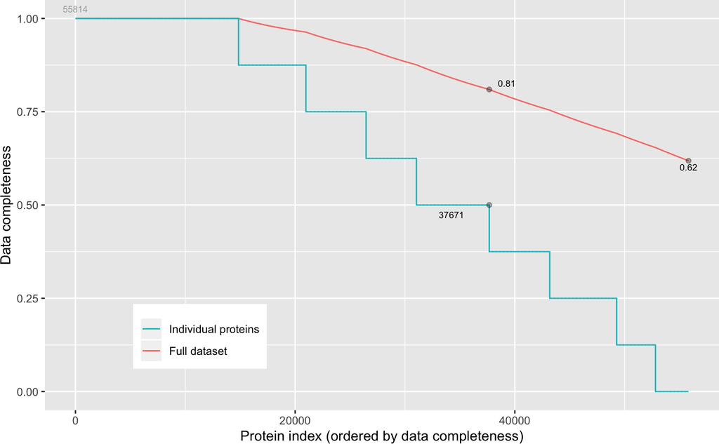

```r
plotNA(pepData)
```

When we look at density plots of the intensities, we see that most intensities are low and that there is a long tail to the right. It is more useful to explore the data upon log transformation.

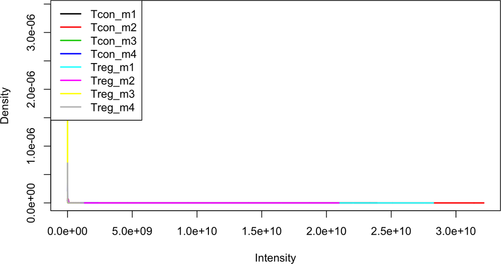

```r
plotDensities(exprs(pepData))
```

```r
nrow(pepData)
```

```
## [1] 55814
```

There are 55814 peptides before preprocessing.

# 3 Preprocessing

We will log transform, normalize, filter and summarize the data.

## 3.1 Log transform the data

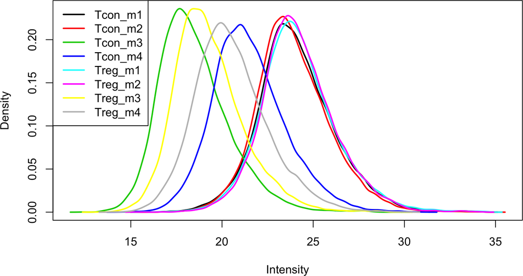

```r
pepData <- log(pepData, base = 2)
plotDensities(exprs(pepData))
```

## 3.2 Filtering

### 3.2.1 Handling overlapping protein groups

In our approach a peptide can map to multiple proteins, as long as there is none of these proteins present in a smaller subgroup.

```r
pepData<-pepData[fData(pepData)$Proteins %in% smallestUniqueGroups(fData(pepData)$Proteins),]
```

### 3.2.2 Remove reverse sequences (decoys) and contaminants

We now remove the contaminants, peptides that map to decoy sequences and proteins, which were only identified by peptides with modifications.

```r
pepData <- pepData[fData(pepData)$Reverse!="+",]
pepData <- pepData[fData(pepData)$Potential.contaminant!="+",]
```

### 3.2.3 Remove peptides of proteins that were only identified with modified peptides

```r
proteinGroups<-read.table(proteinGroupsFile, sep = "\t", header = TRUE, quote = "", comment.char = "")
only_site <- proteinGroups$Only.identified.by.site
only_site[is.na(only_site)] <- ""
proteinsOnlyIdentifiedWithPTMs <- proteinGroups$Protein.IDs[only_site=="+"]
pepData<-pepData[!(fData(pepData)$Proteins %in% proteinsOnlyIdentifiedWithPTMs),]
```

We will now remove the proteinGroups object from the R session to free memory.

```r
rm(proteinGroups,only_site)
gc()
```

```
##           used  (Mb) gc trigger  (Mb) limit (Mb) max used  (Mb)
## Ncells 4158129 222.1    8603494 459.5         NA  5452427 291.2
## Vcells 8237701  62.9   24434430 186.5      16384 24430597 186.4
```

### 3.2.4 Drop peptides that were only identified in one sample

We want to keep peptide that were at least observed twice.

```r
pepData<-pepData[fData(pepData)$nNonZero>=2,]
nrow(pepData)
```

```
## [1] 44396
```

We keep 44396 peptides upon filtering.

## 3.3 Quantile normalize the data

```r
pepData <- normalise(pepData, "quantiles")
```

## 3.4 Explore quantile normalized data

Upon normalisation the density curves for all samples coincide.

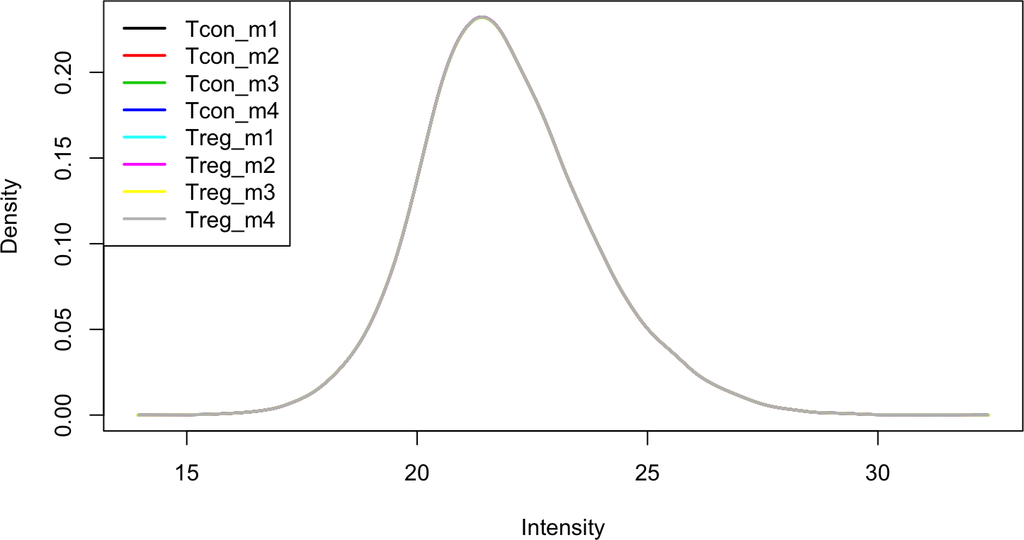

```r
plotDensities(exprs(pepData))
```

We can visualize our data using a Multi Dimensional Scaling plot, eg. as provided by the limma package.

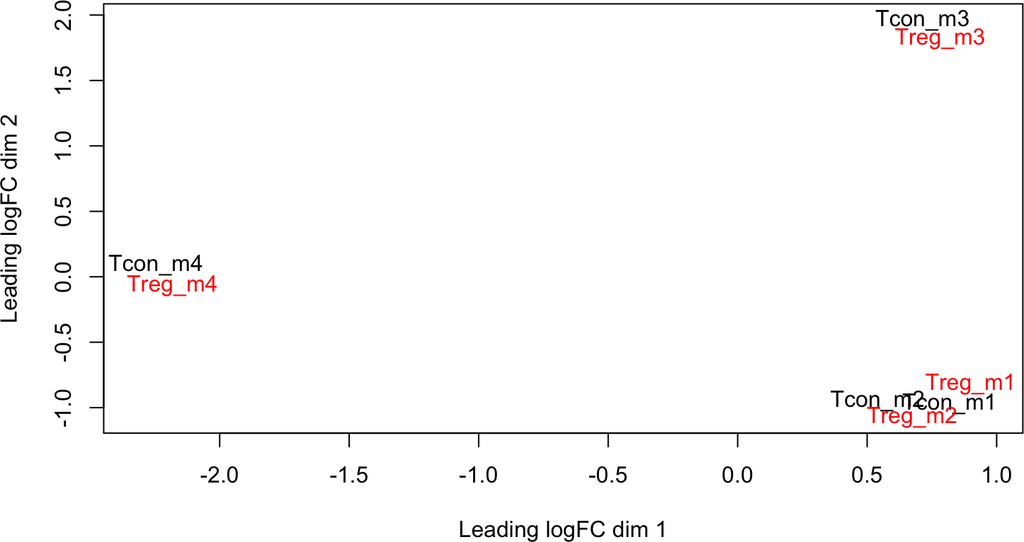

```r
plotMDS(exprs(pepData),col=as.double(pData(pepData)$cellType))
```

## 3.5 Summarization to protein level

```r
protData<-combineFeatures(pepData,fcol="Proteins",method="robust",na.rm=TRUE)
```

```
## Your data contains missing values. Please read the relevant section
## in the combineFeatures manual page for details the effects of
## missing values on data aggregation.
```

If you summarize using robust summarization please refer to Sticker et al. (2019) https://www.biorxiv.org/content/10.1101/668863v1

```r
protData<-protData[
protData %>% exprs %>% is.na %>% `!` %>% rowSums>4,]
```

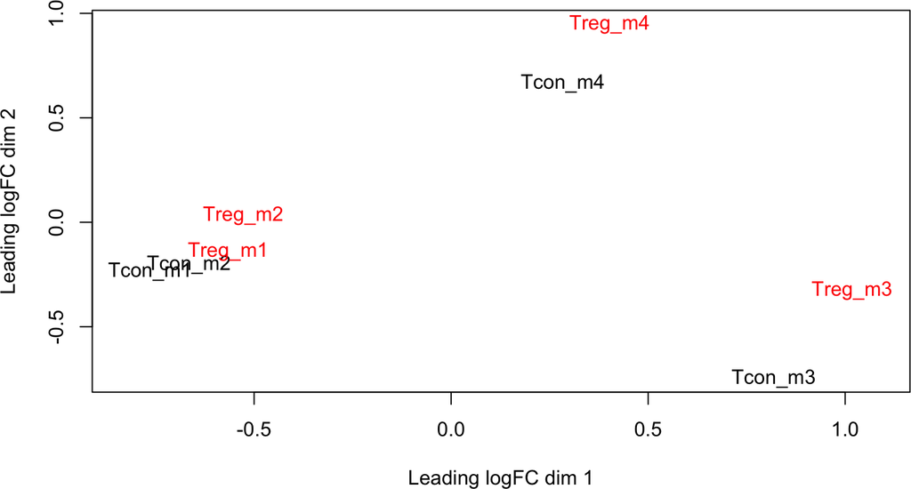

```r
plotMDS(exprs(protData),col=as.double(pData(pepData)$cellType))
```

# 4 Data Analysis

## 4.1 Estimation

MSqRob is currently working with a format where we have one dataframe for each protein. This will be changed in the next release. Therefore we first have to reorganise the data.

```r
protMSqRob <- MSnSet2protdata(protData, "Proteins",annotations=c("Protein.names","Gene.names"))
models <- fit.model(protdata=protMSqRob, response="quant_value", fixed=c("cellType","mouseID"),shrinkage.fixed=c(0,0),robust_var=FALSE)
```

## 4.2 Inference

Many biologists have problems with the reference coding. In MSqRob we have opted to formulate contrasts using all levels of a factor. Internally, the contrasts are than recasted according to the factor level that is the reference class.

```r
L <- makeContrast("cellTypeTreg - cellTypeTcon",  levels=c("cellTypeTreg","cellTypeTcon"))
tests <- test.contrast_adjust(models, L)
nSig <- sum(tests$signif,na.rm=TRUE)
head(tests,nSig)
```

```
##                                                                                                                   Protein.names
## P24452                                                                                               Macrophage-capping protein
## P21550                                                                                                             Beta-enolase
## P08207                                                                                                         Protein S100-A10
## O09131                                                                                        Glutathione S-transferase omega-1
## Q7TPR4                                                                                                          Alpha-actinin-1
## Q9D3P8                                                                                                Plasminogen receptor (KT)
## Q8BGW0                                                                                                           Protein THEMIS
## Q80SU7                                                                                   Interferon-induced very large GTPase 1
## P13020                                                                                                                 Gelsolin
## P07356                                                                                                               Annexin A2
## Q8BFP9                                           [Pyruvate dehydrogenase (acetyl-transferring)] kinase isozyme 1, mitochondrial
## Q9JJU8                                                                       SH3 domain-binding glutamic acid-rich-like protein
## Q9QXY6                                                                                           EH domain-containing protein 3
## Q61205                                                              Platelet-activating factor acetylhydrolase IB subunit gamma
## Q9CYL5                                                                    Golgi-associated plant pathogenesis-related protein 1
## Q61503                                                                                                           5-nucleotidase
## P07091                                                                                                          Protein S100-A4
## Q9DC16                                                           Endoplasmic reticulum-Golgi intermediate compartment protein 1
## P07742                                                                       Ribonucleoside-diphosphate reductase large subunit
## Q99N69                                                                                                                 Leupaxin
## P54071                                                                           Isocitrate dehydrogenase [NADP], mitochondrial
## P16045                                                                                                               Galectin-1
## Q60611                                                                                                DNA-binding protein SATB1
## Q9R1Q7                                                                                                    Proteolipid protein 2
## P70677                                                                    Caspase-3;Caspase-3 subunit p17;Caspase-3 subunit p12
## P30285                                                                                                Cyclin-dependent kinase 4
## Q9QYB5                                                                                                            Gamma-adducin
## Q4QQM4                                                                                   Tumor protein p53-inducible protein 11
## Q9WUU8                                                                                            TNFAIP3-interacting protein 1
## Q3UW53                                                                                                            Protein Niban
## P09055                                                                                                          Integrin beta-1
## Q8BGC4                                                           Zinc-binding alcohol dehydrogenase domain-containing protein 2
## Q64521                                                                        Glycerol-3-phosphate dehydrogenase, mitochondrial
## Q60710                                                                  Deoxynucleoside triphosphate triphosphohydrolase SAMHD1
## P57016                                                                                                                Ladinin-1
## Q03267                                                                                               DNA-binding protein Ikaros
## Q8CG47                                                                          Structural maintenance of chromosomes protein 4
## P42230                                                                      Signal transducer and activator of transcription 5A
## P15307                                                                                                     Proto-oncogene c-Rel
```

[output cut: 344 more lines]

```
## P54227 0.047665023   TRUE
## Q8R001 0.047665023   TRUE
## Q6P9R4 0.049152247   TRUE
## Q8R502 0.049152247   TRUE
## C3VPR6 0.049472783   TRUE
## P28867 0.049472783   TRUE
## P49717 0.049472783   TRUE
## Q68FL4 0.049472783   TRUE
## P51855 0.049472783   TRUE
## Q9CXJ1 0.049547668   TRUE
## Q99ME2 0.049547668   TRUE
## P97311 0.049547668   TRUE
## P10630 0.049873794   TRUE
## Q921I1 0.049873794   TRUE
## Q9D0K2 0.049873794   TRUE
```

There are 132 proteins with a significant effect at the 5% FDR level.

## 4.3 Plots

### 4.3.1 Volcano-plot

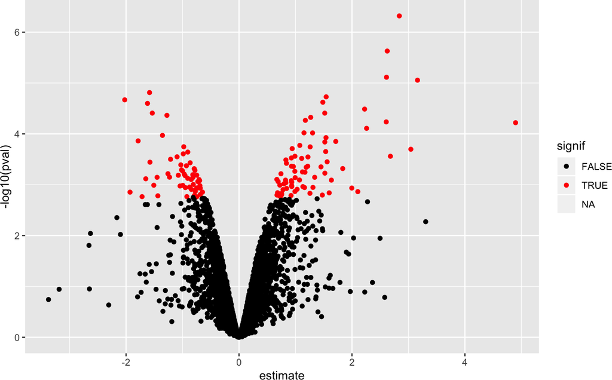

```r
volcano<- ggplot(tests,aes(x=estimate,y=-log10(pval),color=signif)) + geom_point() + scale_color_manual(values=c("black","red"))
volcano
```

An interactive volcano plot can be obtained by using the plotly library. We alter the object tests to add the protein name to the data frame in ggplot, this will allow us to see the protein name in the interactive plot.

```r
library(plotly)
volcano<- ggplot(tests %>% rownames_to_column("protein"), aes(x=estimate,y=-log10(pval),color=signif,protein=protein,annotation=Protein.names,gene=Gene.names)) + geom_point() + scale_color_manual(values=c("black","red"))
ggplotly(volcano)
```

### 4.3.2 Heatmap

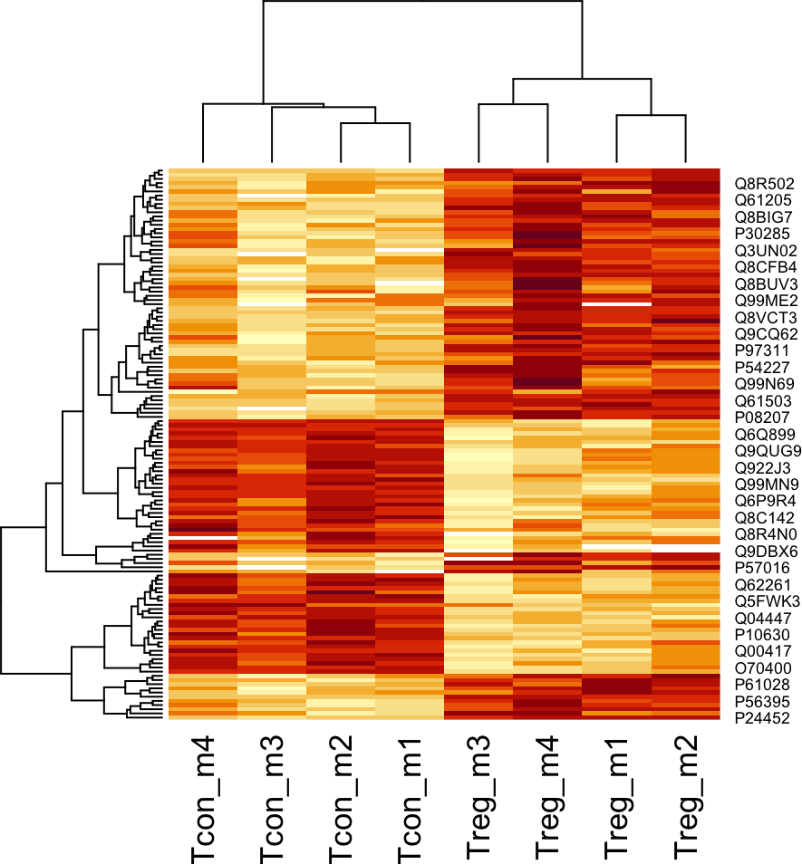

```r
sigNames<- tests %>% rownames_to_column("protein") %>% filter(signif) %>% pull(protein)
heatmap(exprs(protData)[sigNames,])
```

### 4.3.3 Detail plot for the top 5 proteins.

We first extract the normalized protein expression values for a particular protein and we create a dataframe that contains the protein expression values and the relevant variables of the experimental design.

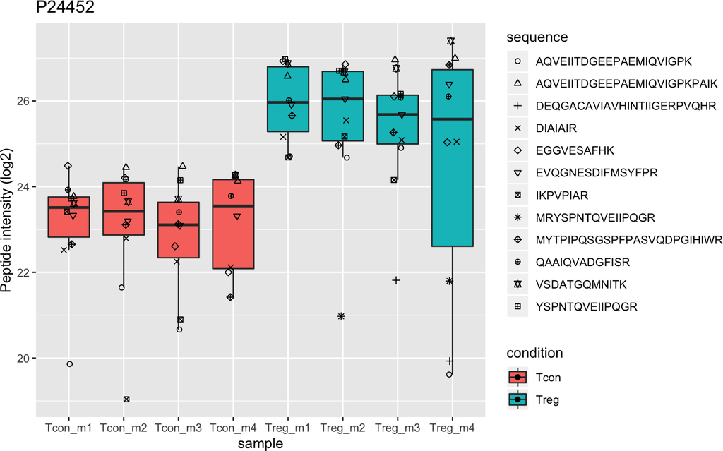

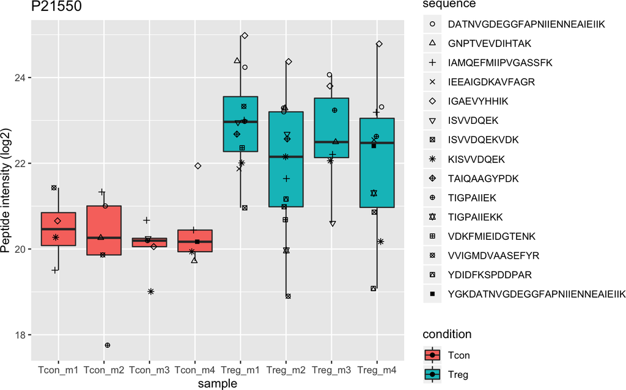

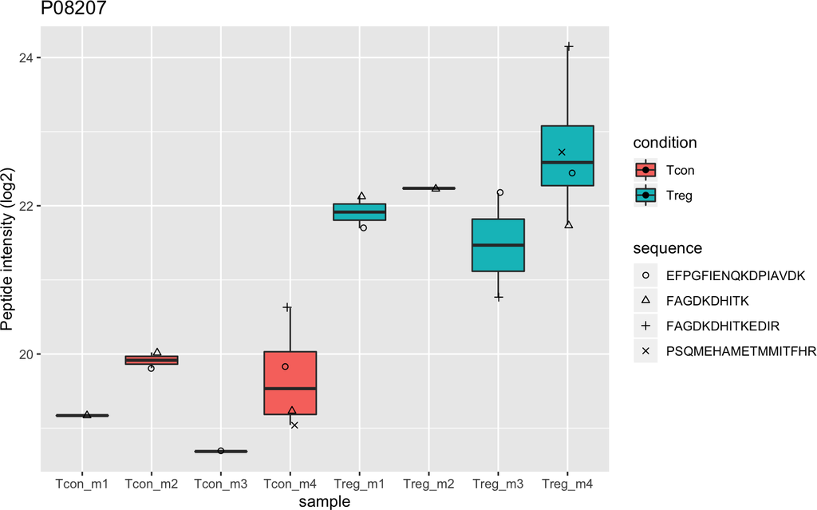

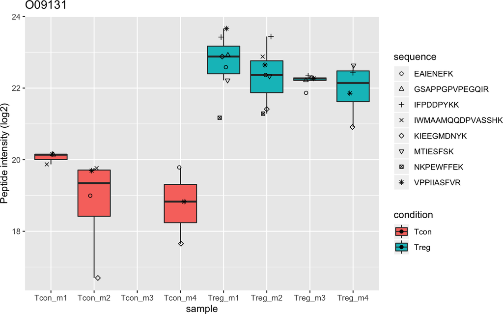

[figure not shown]

```r
for (protName in rownames(tests)[1:5])
{
plotDat<-pepData[fData(pepData)$Proteins==protName] %>% exprs
plotDataStack<-data.frame(quant_value=c(plotDat),sequence=rep(rownames(plotDat),rep=ncol(plotDat)),sample=rep(colnames(plotDat),each=nrow(plotDat)),condition=rep(pData(pepData)$cellType,each=nrow(plotDat)))
plot1 <- ggplot(plotDataStack, aes(x=sample, y=quant_value,fill=condition))
print(plot1 +geom_boxplot(outlier.shape=NA) + geom_point(position=position_jitter(width=.1),aes(shape=sequence)) + scale_shape_manual(values=1:nrow(plotDat)) +labs(title = protName, x="sample", y="Peptide intensity (log2)"))
}
```